# Unsupervised learning

김권현

2018년 12월 8일

# 비지도 학습(Unsupervised Learning)

## 주성분분석(PCA; Principal Component Analysis)

- 적용 대상 : 변수갯 갯수가 많고, 서로 상관이 클 때
- 목적 : 자료의 **분산**을 가장 잘 설명하는 성분(component)를 찾아낸다.
- 탐색적자료분석(exploratory data analysis), 차원 축소(dimension reduction), 또는 자료의 시각화(visualization)를 위해 사용된다.
- 주성분(PC; Principal Component)은 기존 변수의 선형 결합이다.

$$\text{PC} = w_1 x_1 + w_2 x_2 + \cdots + w_p x_p, \ \ w_1^2 + w_2^2 + \cdots + w_p^2 = 1$$

- 각 성분은 서로 **직교**한다. 따라서, $k$-번째 주성분(PC; Principal Component)과 $l$-번째 주성분은 서로 직교한다.

$$w_{k1}w_{l1} + w_{k2}w_{l2} + \cdots + w_{kp}w_{lp} = 0$$

$$\text{PC}_k = w_{k1} x_1 + w_{k2} x_2 + \cdots + w_{kp} x_p, \ \ w_{1i}^2 + w_{2i}^2 + \cdots + w_{pi}^2 = 1$$

### 2변수의 경우

다음의 조건을 만족하는 두 주성분을 구하고자 한다.

$$PC_1 = w_{11} x_1 + w_{12} x_2$$
$$PC_2 = w_{21} x_1 + w_{22} x_2$$

이때 $PC_1^2 + PC_2^2 = x_1^2 + x_2^2$을 만족해야 한다면 다음과 같이 전개할 수 있다.

$$PC_1^2 + PC_2^2 = (w_{11} x_1 + w_{12} x_2)^2 + (w_{21} x_1 + w_{22} x_2)^2$$

그리고 모든 $x_1$, $x_2$에 대해 위의 식이 성립하려면 $w_{11}^2 + w_{21}^2 = 1$, $w_{21}^2 + w_{22}^2 =1$과 $w_{11}+w_{12} + w_{21}w_{22} = 0$을 만족해야 한다. 이는 2차원 평면 상에서 회전 변환을 취한 것과 같다.

### 예: `BaseballHitters.csv`

```r
iTest <- c(177,294,44,220,215,25,81,111,107,284,216,36,18,56,91,320,113,194,
           321,151,7 ,19,242,123,221,230,45,277,54,228,156,298,92,121,181,
           243,191,68,118,55,264,153 ,125,102,75,32,303,317,106,252,149,70,
           316,293,40,310,90,100,258,15)

#dat <- read.csv('./00_Instructor/W11_MultipleRegression/BaseballHitters.csv', row.names=1)
dat <- read.csv('../W11_MultipleRegression/BaseballHitters.csv', row.names=1)
#getwd()
#sum(is.na(datTrain$salary87))
#sum(is.na(datTest$salary87))
library(dplyr)
datTrain <- dat %>% slice(-iTest) %>% filter(!is.na(salary87))
```

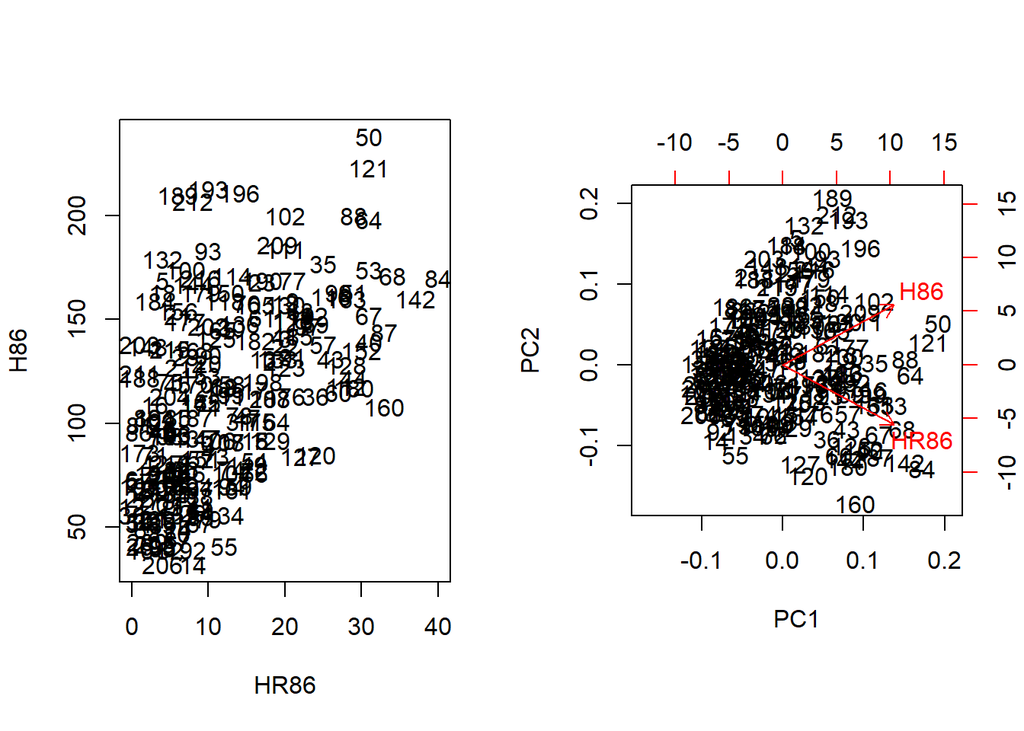

```r
datTest <- dat %>% slice(iTest) %>% filter(!is.na(salary87))

fitPCA <- prcomp(~ H86 + HR86, data=datTrain, scale.=TRUE)
par(mfcol=c(1,2))
datTrain$i = 1:nrow(datTrain)
plot(H86 ~ HR86, data=datTrain, pch='')
text(datTrain$HR86, datTrain$H86, labels= datTrain$i, add=T)
biplot(fitPCA)
```

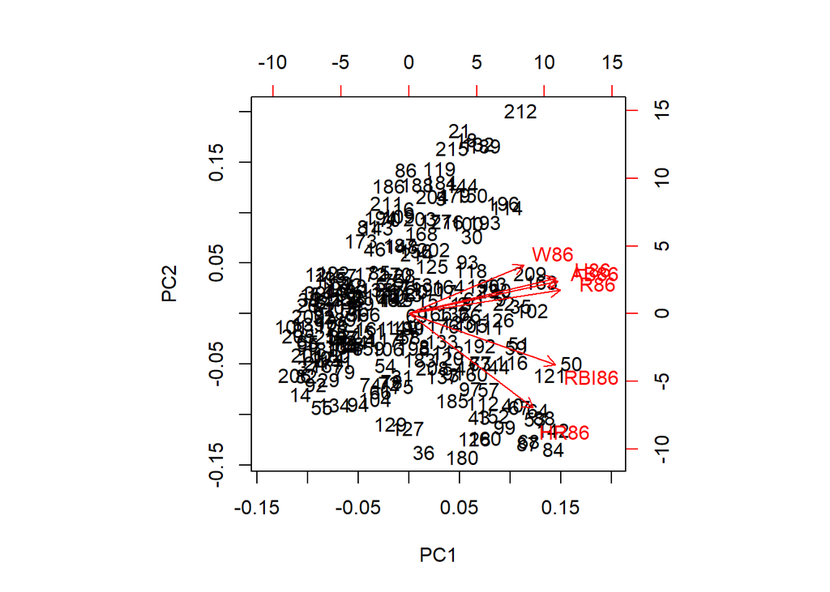

```r
par(mfcol=c(1,1))

fitPCA <- prcomp(~ AB86 + H86 + HR86 + R86 + RBI86 + W86, data=datTrain, scale.=TRUE)
#pdf('biplot.pdf', height=12, width=12)
biplot(fitPCA)
```

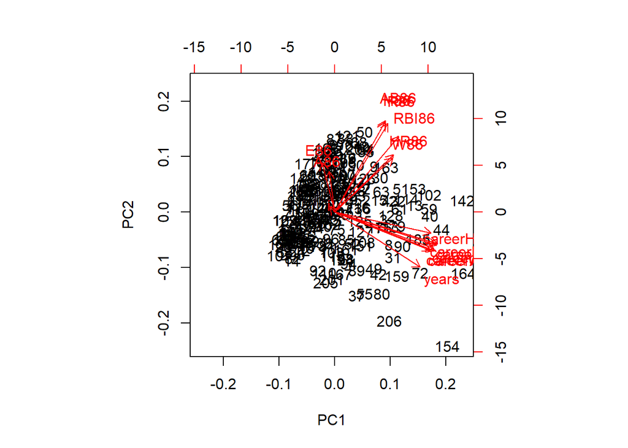

```r
#dev.off()

fitPCA <- prcomp(~ . - firstName - lastName - salary87 - league87 - team87 - position86 - PO86 - division86 - team86 - league86, data=datTrain, scale.=TRUE)
biplot(fitPCA)
```

## 군집화

- K-평균 군집화(K-means Clustering)
- 위계적(계층적) 군집화(Hierarchical Clustering)

### K-평균 군집화

- K-평균의 군집은 군집 평균으로 대표될 수 있다.
- 한 군집 내의 대상들은 다른 군집의 군집 평균보다 같은 군집의 군집 평균에 더 가깝다.
- 군집의 군집 평균은 동일한 군집의 평균이 된다.
- 알고리즘
  - 1. 군집의 갯수를 정한다.
  - 2. 각 군집에 대해 군집 평균을 설정한다.
  - 3. 모든 대상에 대해 군집 평균이 가까운 군집으로 군집화한다.
  - 4. 모든 군집에 대해 군집 평균을 다시 구한다.
  - 5. 조건이 맞으면 종료하고, 그렇지 않으면 2번으로 되돌아간다.

### 위계적 군집화

- 위계적 군집화는 병합(agglomerative) 군집화와 분할(divisive) 군집화로 나뉜다.
- 병합 군집화는 모든 사례에서 시작해서 가까운 사례를 묶어 군집을 구성한다.
- 분할 군집화는 모든 사례에서 시작해서 가장 먼 사례를 분할한다.
- 옵션
  - 어떤 거리(distance) 또는 유사도(similarity)를 사용할 것인가?
  - 변수를 표준화할 것인가?
  - type of linkage?
  - 덴도그램을 자를 높이?
  - K-평균에서 군집을 몇 개로 할 것인가?
- 모형 검증 in 군집화
- outliers that do not belong to any cluster

### 예: `USArrests`

```r
fit <- prcomp(USArrests)
plot(fit)
biplot(fit)

fit$center
fit$scale
fit$rotation

fit0 <- prcomp(~ . - UrbanPop, data=USArrests)
# prcomp(~ Murder + Assault + Rape, data=USArrests)
print(fit0)

fit <- prcomp(~ . - UrbanPop, data=USArrests, center=TRUE, scale.=TRUE)
print(fit)
biplot(fit)
```

[output not shown]

### 예:

```r
kmeans(USArrests, 2)
```

```
## K-means clustering with 2 clusters of sizes 29, 21
##
## Cluster means:
##      Murder  Assault UrbanPop     Rape
## 1  4.841379 109.7586 64.03448 16.24828
## 2 11.857143 255.0000 67.61905 28.11429
##
## Clustering vector:
##        Alabama         Alaska        Arizona       Arkansas     California
##              2              2              2              2              2
##       Colorado    Connecticut       Delaware        Florida        Georgia
##              2              1              2              2              2
##         Hawaii          Idaho       Illinois        Indiana           Iowa
##              1              1              2              1              1
##         Kansas       Kentucky      Louisiana          Maine       Maryland
##              1              1              2              1              2
##  Massachusetts       Michigan      Minnesota    Mississippi       Missouri
##              1              2              1              2              1
##        Montana       Nebraska         Nevada  New Hampshire     New Jersey
##              1              1              2              1              1
##     New Mexico       New York North Carolina   North Dakota           Ohio
##              2              2              2              1              1
##       Oklahoma         Oregon   Pennsylvania   Rhode Island South Carolina
##              1              1              1              1              2
##   South Dakota      Tennessee          Texas           Utah        Vermont
##              1              2              2              1              1
##       Virginia     Washington  West Virginia      Wisconsin        Wyoming
##              1              1              1              1              1
##
## Within cluster sum of squares by cluster:
## [1] 54762.30 41636.73
##  (between_SS / total_SS =  72.9 %)
##
## Available components:
##
## [1] "cluster"      "centers"      "totss"        "withinss"
## [5] "tot.withinss" "betweenss"    "size"         "iter"
## [9] "ifault"
```

```r
kmeans(USArrests, 3)
```

```
## K-means clustering with 3 clusters of sizes 20, 14, 16
##
## Cluster means:
##      Murder  Assault UrbanPop     Rape
## 1  4.270000  87.5500 59.75000 14.39000
## 2  8.214286 173.2857 70.64286 22.84286
## 3 11.812500 272.5625 68.31250 28.37500
##
## Clustering vector:
##        Alabama         Alaska        Arizona       Arkansas     California
##              3              3              3              2              3
##       Colorado    Connecticut       Delaware        Florida        Georgia
##              2              1              3              3              2
##         Hawaii          Idaho       Illinois        Indiana           Iowa
##              1              1              3              1              1
##         Kansas       Kentucky      Louisiana          Maine       Maryland
##              1              1              3              1              3
##  Massachusetts       Michigan      Minnesota    Mississippi       Missouri
##              2              3              1              3              2
##        Montana       Nebraska         Nevada  New Hampshire     New Jersey
##              1              1              3              1              2
##     New Mexico       New York North Carolina   North Dakota           Ohio
##              3              3              3              1              1
##       Oklahoma         Oregon   Pennsylvania   Rhode Island South Carolina
##              2              2              1              2              3
##   South Dakota      Tennessee          Texas           Utah        Vermont
##              1              2              2              1              1
##       Virginia     Washington  West Virginia      Wisconsin        Wyoming
##              2              2              1              1              2
##
## Within cluster sum of squares by cluster:
## [1] 19263.760  9136.643 19563.863
##  (between_SS / total_SS =  86.5 %)
##
## Available components:
##
## [1] "cluster"      "centers"      "totss"        "withinss"
## [5] "tot.withinss" "betweenss"    "size"         "iter"
## [9] "ifault"
```

```r
hclust(dist(USArrests))
```

```
##
## Call:
## hclust(d = dist(USArrests))
##
## Cluster method   : complete
## Distance         : euclidean
## Number of objects: 50
```

## 군집화 정리

- 군집화의 목적 : 군집 내의 유사도는 크고, 군집 간의 유사도는 작은 군집을 찾아낸다.
- 변수의 단위(예. m, cm, mm 등)가 중요한 영향을 미친다. 모든 변수의 단위를 적절히 조정해야 한다. 한 가지 방법은 모든 변수를 평균 0, 표준편차 1로 변환하는 것이다(표준화; standardization).
- 군집화 방법과 군집 갯수에 따라 서로 다른 군집화 결과가 나타나기 마련이다.